# Assignment 2 Task 1

Justine Lang

2023-02-21

```r
knitr::opts_chunk$set(echo = TRUE, message = FALSE, warning = FALSE)

library(tidyverse)
library(here)
library(GGally)
library(broom)
library(AICcmodavg)
library(kableExtra)
library(tidymodels)
```

## Data Overview

This report analyzes and compares data on two different palmetto species, *Serenoa repens* and *Sabal etonia*, from Archbold Biological Station in south-central Florida. Annual data were collected from 1981 to 1997 and from 2001 to 2017, and include measures of plant height, canopy length and width, and number of green leaves (Abrahamson, 2019). In this analysis, binary logistic regression was used to test the feasibility of using these variables to classify whether a palmetto is *Serenoa repens* or *Sabal etonia*.

## Data Visualization

Visualizations of differences in height, canopy length, canopy width, and green leaves for *Serenoa repens* and *Sabal etonia*.

```r
#Read in the data

palmetto <- read_csv(here("data", "palmetto.csv"))
```

### Data Wrangling

```r
#Rename species codes to species names

palmetto_names <- palmetto %>%
   mutate(species = case_when(species == "1" ~ "Serenoa repens",
    species == "2" ~ "Sabal etonia"))

#Subset the data

palmetto_subset <- palmetto_names %>%
  select(species, height:green_lvs) %>%
  drop_na()

#Convert species to a factor
palmetto_subset$species <- as.factor(palmetto_subset$species)

#class(palmetto_subset$species)
#levels(palmetto_subset$species)
```

### Create Graphs

```r
#Explore potential trends

#ggpairs(palmetto_subset, aes(color = species))
### Height & length, height & width, green leaves & species look like good relationships to visualize
```

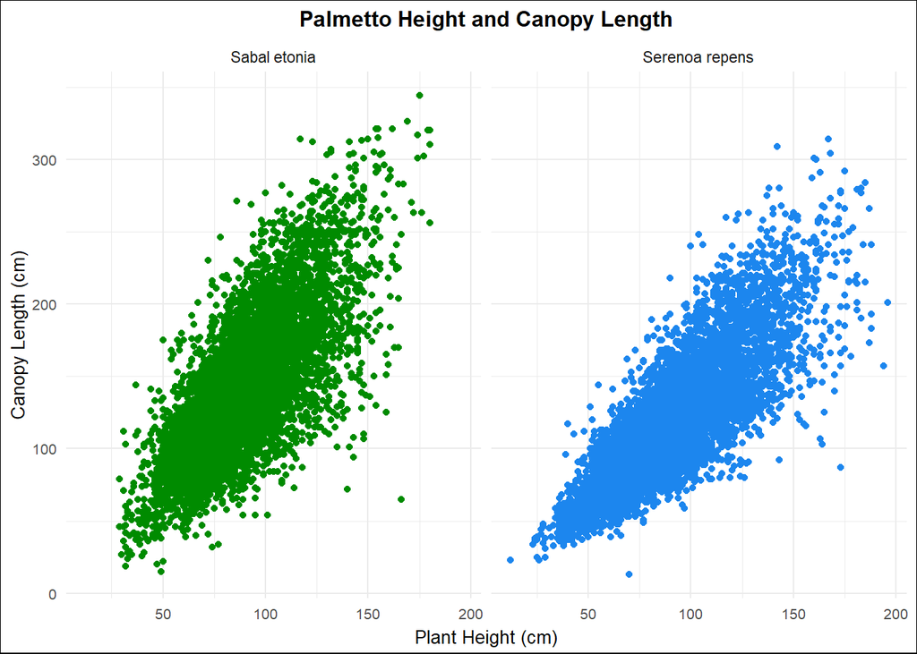

Figure 1: The relationship between plant height (cm) and canopy length (cm) for two palmetto species, observed from 1981 to 2017.

```r
#Create the first figure

height_length_gg <- ggplot(data = palmetto_subset, aes(x = height, y = length)) +
  geom_point(aes(color = species), show.legend = FALSE) +
  facet_wrap(~species) +
  theme_minimal() +
  labs( x = "Plant Height (cm)",
        y = "Canopy Length (cm)",
        title = "Palmetto Height and Canopy Length") +
  theme(plot.title = element_text(hjust = 0.5, face = "bold", size = 12),
        axis.title.x = element_text(vjust = 0.2, size = 10),
        axis.title.y = element_text(size = 10),
        axis.text = element_text(size = 8),
        plot.background = element_rect(fill = "white"))+
  scale_color_manual(values = c("green4", "dodgerblue2"))

height_length_gg
```

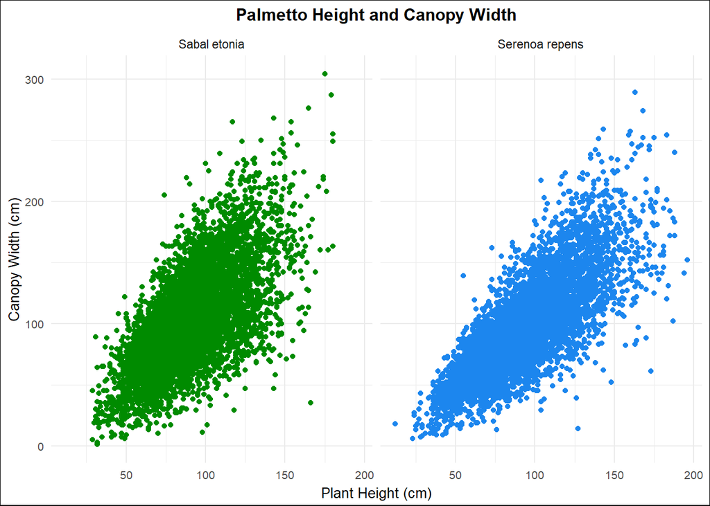

Figure 2: The relationship between plant height (cm) and canopy width (cm) for two palmetto species, observed from 1981 to 2017.

```r
#Create the second figure

height_width_gg <- ggplot(data = palmetto_subset, aes(x = height, y = width)) +
  geom_point(aes(color = species), show.legend = FALSE) +
  facet_wrap(~species) +
  theme_minimal() +
  labs( x = "Plant Height (cm)",
        y = "Canopy Width (cm)",
        title = "Palmetto Height and Canopy Width") +
  theme(plot.title = element_text(hjust = 0.5, face = "bold", size = 12),
        axis.title.x = element_text(vjust = 0.2, size = 10),
        axis.title.y = element_text(size = 10),
        axis.text = element_text(size = 8),
        plot.background = element_rect(fill = "white")) +
  scale_color_manual(values = c("green4", "dodgerblue2"))

height_width_gg
```

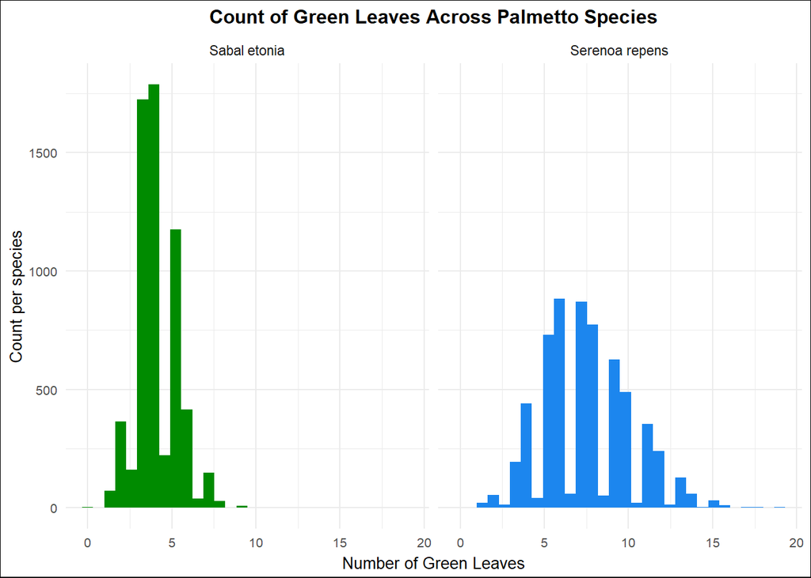

Figure 3: A histogram comparing the number of green leaves between two palmetto species, observed from 1981 to 2017.

```r
#Create the third figure

leaves_gg <- ggplot(data = palmetto_subset, aes(x = green_lvs, fill = species)) +
  geom_histogram() +
  facet_wrap(~species) +
  theme_minimal() +
  labs( x = "Number of Green Leaves",
        y = "Count per species",
        title = "Count of Green Leaves Across Palmetto Species") +
  theme(plot.title = element_text(hjust = 0.5, face = "bold", size = 12),
        axis.title.x = element_text(vjust = 0.2, size = 10),
        axis.title.y = element_text(size = 10),
        axis.text = element_text(size = 8),
        plot.background = element_rect(fill = "white"),
        legend.position = "none")+
  scale_fill_manual(values = c("green4", "dodgerblue2"))

leaves_gg
```

Based on these plots, the easiest way to classify each species would be to count the number of green leaves. There is more overlap between their height, canopy length, and canopy width, though looking at a combination of the variables could further help narrow down classification.

## Binary Logistic Regression

### Create Models

```r
#Log odds of plant type using plant height, canopy length, canopy width, and green leaves as predictor variable.

f1 <- species ~ height + length + width + green_lvs

palmetto_blr1 <- glm(formula = f1,
                    data = palmetto_subset,
                    family = "binomial")

#Log odds of plant type using plant height, canopy width, and green leaves

f2 <- species ~ height + width + green_lvs

palmetto_blr2 <- glm(formula = f2,
                    data = palmetto_subset,
                    family = "binomial")
```

### AIC and BIC

```r
#AIC

aictab(list(palmetto_blr1, palmetto_blr2)) %>%
    kable(col.names = c("Model", "Parameters", "AIC", "Delta AIC", "Model Likelihood", "AIC Weight", "Log Likelihood", "Cumulative Weight"),
        caption = "Table 1: AIC Results") %>%
  kable_classic(position = "center")
```

Table 1: AIC Results

| Model | Parameters | AIC | Delta AIC | Model Likelihood | AIC Weight | Log Likelihood | Cumulative Weight |
| --- | --- | --- | --- | --- | --- | --- | --- |
| Mod1 | 5 | 5194.567 | 0.0000 | 1 | 1 | -2592.281 | 1 |
| Mod2 | 4 | 5987.475 | 792.9086 | 0 | 0 | -2989.736 | 1 |

```r
#BIC

bictab(list(palmetto_blr1, palmetto_blr2)) %>%
    kable(col.names = c("Model", "Parameters", "BIC", "Delta BIC", "Model Likelihood", "BIC Weight", "Log Likelihood", "Cumulative Weight"),
        caption = "Table 2: BIC Results") %>%
  kable_classic(position = "center")
```

Table 2: BIC Results

| Model | Parameters | BIC | Delta BIC | Model Likelihood | BIC Weight | Log Likelihood | Cumulative Weight |
| --- | --- | --- | --- | --- | --- | --- | --- |
| Mod1 | 5 | 5231.635 | 0.0000 | 1 | 1 | -2592.281 | 1 |
| Mod2 | 4 | 6017.131 | 785.4956 | 0 | 0 | -2989.736 | 1 |

### Repeated Cross Validation

```r
#Set seed for reproducibility

set.seed(123)

#Set folds

tidy_folds <- vfold_cv(palmetto_subset, v = 10, repeats = 5)

#Use a workflow that bundles the logistic model and a formula

 blr_model <- logistic_reg() %>%
   set_engine('glm')

blr_tidy_wf1 <- workflow() %>%
  add_model(blr_model) %>%
  add_formula(f1)

blr_tidy_cv_f1 <- blr_tidy_wf1 %>%
  fit_resamples(tidy_folds)

#Use functions from the tune package to extract metrics

metrics1<- collect_metrics(blr_tidy_cv_f1)

#Make a table to display model 1 metrics from CV

nice_metrics<- metrics1 %>%
  kable(col.names = c("Metric", "Estimator", "Mean", "n", "Standard Error", "Configuration"),
        caption = "Table 3: Cross Validation Metrics Model 1") %>%
  kable_classic(position = "center")

nice_metrics
```

Table 3: Cross Validation Metrics Model 1

| Metric | Estimator | Mean | n | Standard Error | Configuration |
| --- | --- | --- | --- | --- | --- |
| accuracy | binary | 0.9167681 | 50 | 0.0009694 | Preprocessor1_Model1 |
| roc_auc | binary | 0.9724764 | 50 | 0.0005070 | Preprocessor1_Model1 |

```r
#Mean accuracy is 0.9168 for model 1

#Repeat for model 2

blr_tidy_wf2 <- workflow() %>%
  add_model(blr_model) %>%
  add_formula(f2)

blr_tidy_cv_f2 <- blr_tidy_wf2 %>%
  fit_resamples(tidy_folds)

#Use functions from the tune package to extract metrics

metrics2<- collect_metrics(blr_tidy_cv_f2)

nice_metrics_2<- metrics2 %>%
  kable(col.names = c("Metric", "Estimator", "Mean", "n", "Standard Error", "Configuration"),
        caption = "Table 4: Cross Validation Metrics Model 2") %>%
  kable_classic(position = "center")

nice_metrics_2
```

Table 4: Cross Validation Metrics Model 2

| Metric | Estimator | Mean | n | Standard Error | Configuration |
| --- | --- | --- | --- | --- | --- |
| accuracy | binary | 0.8988172 | 50 | 0.0011213 | Preprocessor1_Model1 |
| roc_auc | binary | 0.9634307 | 50 | 0.0005842 | Preprocessor1_Model1 |

```r
#Mean accuracy is 0.8988 for model 2
```

AIC, BIC, and the repeated cross validation all indicate that Model 1 performs better. AIC and BIC were lower for Model 1. Mean accuracy was greater (0.9168) for Model 1 than mean accuracy (0.8988) for Model 2. These results indicate that Model 1 is the better fit.

## Final Model

```r
#Use the entire dataset to identify the coefficients for the final predictive model based on Model 1

blr_tidyfit_f1 <- blr_model %>%
  fit(f1, data = palmetto_subset)
coefficient_df <- blr_tidyfit_f1 %>%
  tidy() %>%
  kable(col.names = c("Term", "Estimate","Standard Error", "Statistic", "P-Value"),
        caption = "Table 5: Coefficients for Final Predictive Model") %>%
  kable_classic(position = "center")

coefficient_df
```

Table 5: Coefficients for Final Predictive Model

| Term | Estimate | Standard Error | Statistic | P-Value |
| --- | --- | --- | --- | --- |
| (Intercept) | -3.2266851 | 0.1420708 | -22.71180 | 0 |
| height | 0.0292173 | 0.0023061 | 12.66984 | 0 |
| length | -0.0458233 | 0.0018661 | -24.55600 | 0 |
| width | -0.0394434 | 0.0021000 | -18.78227 | 0 |
| green_lvs | 1.9084747 | 0.0388634 | 49.10728 | 0 |

```r
#Find probabilities associated with a palmetto being S. etonia or S. repens based on Model 1

blr1_fitted <- palmetto_blr1 %>%
  broom::augment(type.predict = "response") %>%

#Add columns to see if the model correctly guessed the species

  mutate(species_predicted= case_when(.fitted >= 0.5 ~ "Serenoa repens",
         TRUE ~ "Sabal etonia")) %>%
  mutate(correct_prediction= case_when(species == species_predicted ~ "yes",
                                        TRUE ~ "no"))
#Create table

palmetto_table <- blr1_fitted %>%
  select(species, correct_prediction) %>%
  pivot_wider(names_from = correct_prediction, values_from = correct_prediction, values_fn =   list(correct_prediction = length)) %>%
  mutate(percent_correctly_classified= yes/(yes+no)*100)
nice_palmetto_table<- palmetto_table %>%
 kable(col.names = c("Species", "Correctly Classified", "Incorrectly Classified", "Percent Correctly Classified"),
       caption = "Table 6: Classification Results using Model 1") %>%
 kable_classic(position = "center")

nice_palmetto_table
```

Table 6: Classification Results using Model 1

| Species | Correctly Classified | Incorrectly Classified | Percent Correctly Classified |
| --- | --- | --- | --- |
| Serenoa repens | 5548 | 564 | 90.77225 |
| Sabal etonia | 5701 | 454 | 92.62388 |

## Conclusion

Based on this analysis, Model 1 (using plant height, canopy length, canopy width, and green leaves) predicts species better than Model 2 (using just plant height, canopy width, and green leaves). The lower AIC and BIC and higher mean accuracy support Model 1 as the better fit. Through Model 1, 91% of the palmetto plants were correctly classified as *Serenoa repens* and 93% were correctly classified as *Sabel etonia*. These numbers indicate there is a high probability of correctly classifying a palmetto species based on this model.

## Citation

Abrahamson, W.G. 2019. Survival, growth and biomass estimates of two dominant palmetto species of south-central Florida from 1981 - 2017, ongoing at 5-year intervals ver 1. Environmental Data Initiative. https://doi.org/10.6073/pasta/f2f96ec76fbbd4b9db431c79a770c4d5